# Home_work_3

Тимофеев Игорь, 391 гр.

28 ноября 2016 г

## Гипотезы:

Нулевая гипотеза : Данные распределены равномерно, разбиение на кластеры не имеет смысла, то есть не найдется такого разбиения, что какая-то из переменных будет иметь статистически значемую взаимосвязь с этим разбиением.

Альтернативная гипотеза: Существует такое разбиение на кластеры, что какая-то из переменных будет иметь статистически значимую взаимосвязь с этим разбиением.

Подгружаем данные.

```r
setwd("~/Загрузки/Книги/Программирование/Теорвер/Zadachi_na_klasterizatsiyu/08_Сегментация покупателей")
Edmins=read.csv("Покупатели for spss.csv",header = T, sep = ";",fileEncoding = "UCS-2LE")
Edmins_Up=Edmins
```

Посмотрим на них.

```
## 'data.frame':    184 obs. of  5 variables:
##  $ пол      : int  1 1 1 1 1 1 1 1 1 1 ...
##  $ возраст  : int  2 3 1 2 2 2 1 1 1 2 ...
##  $ Телеканал: int  1 1 1 1 1 1 1 1 1 1 ...
##  $ Профессия: int  1 1 3 3 2 2 2 3 3 1 ...
##  $ Пресса   : int  1 4 2 2 2 4 2 2 2 2 ...
```

Стандартизируем(z-преобразованием):

```
## 'data.frame':    184 obs. of  5 variables:
##  $ пол      : num [1:184, 1] 0.431 0.431 0.431 0.431 0.431 ...
##   ..- attr(*, "scaled:center")= num 0.842
##   ..- attr(*, "scaled:scale")= num 0.365
##  $ возраст  : num [1:184, 1] -0.619 0.346 -1.585 -0.619 -0.619 ...
##   ..- attr(*, "scaled:center")= num 2.64
##   ..- attr(*, "scaled:scale")= num 1.04
##  $ Телеканал: num [1:184, 1] -1.26 -1.26 -1.26 -1.26 -1.26 ...
##   ..- attr(*, "scaled:center")= num 2.68
##   ..- attr(*, "scaled:scale")= num 1.33
##  $ Профессия: num [1:184, 1] -2.25 -2.25 1.89 1.89 -0.18 ...
##   ..- attr(*, "scaled:center")= num 2.09
##   ..- attr(*, "scaled:scale")= num 0.483
##  $ Пресса   : num [1:184, 1] -0.9 2.205 0.135 0.135 0.135 ...
##   ..- attr(*, "scaled:center")= num 1.87
##   ..- attr(*, "scaled:scale")= num 0.966
```

Теперь попробуем сделать иерархический кластерный анализ.

Для начала посмотрим на график “каменной осыпи”:

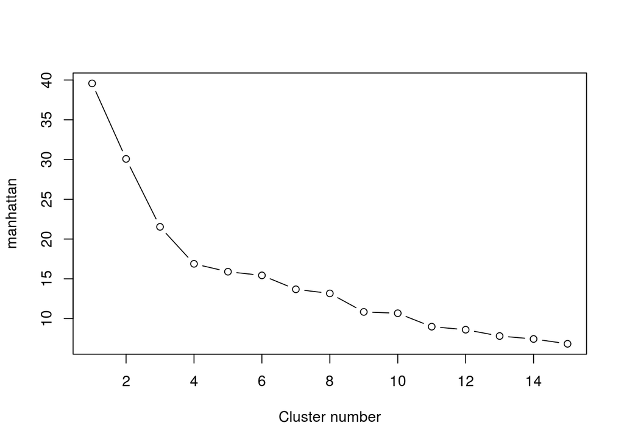

Получится такая картина:

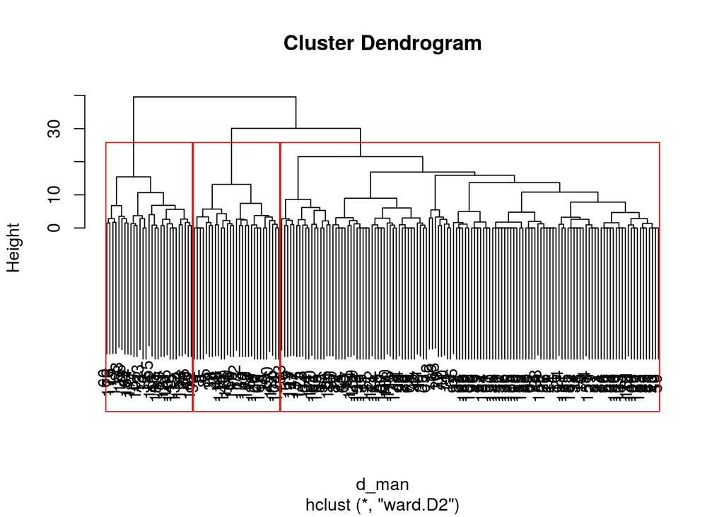

Построим проекцию наших данных на плоскость:

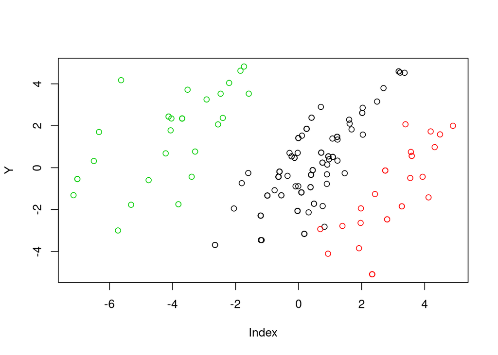

Теперь посмотрим на то как переменные разбиваются по кластерам:

```r
table(Edmins$clusters, Edmins_Up$пол)
```

```
##
##       0   1
##   1   0 126
##   2   0  29
##   3  29   0
```

```r
table(Edmins$clusters, Edmins_Up$возраст)
```

```
##
##      1  2  3  4  5
##   1 10 53 35 24  4
##   2 10  4  9  3  3
##   3  2 12 10  4  1
```

```r
table(Edmins$clusters, Edmins_Up$Телеканал)
```

```
##
##      1  2  3  4  5
##   1 33 29 29 16 19
##   2  7  5 11  3  3
##   3  5  8  9  4  3
```

```r
table(Edmins$clusters, Edmins_Up$Профессия)
```

```
##
##       1   2   3
##   1   8 118   0
##   2   0   0  29
##   3   6  22   1
```

```r
table(Edmins$clusters, Edmins_Up$Пресса)
```

```
##
##      1  2  3  4  5
##   1 53 52 11  7  3
##   2  5 18  6  0  0
##   3 19  2  4  3  1
```

Посмотрим повнимательнее, какая здесь взаимосвязь с помощью дисперсионного анализа:

```
## [1] 0.000000e+00 6.677092e-01 9.785919e-01 1.593193e-45 5.846176e-01
```

Вектор p соответствует p-value для взаимосвязи каждой из 5 независимых переменных с перменной кластеров. Видно, что взаимосвязь есть только у переменной пола и профессии, при чем в первом случае практически абсолютная(p значение равно нулю с нашей точностью), а во втором случае p значение также практически нулевое. Конкретнее можно сказать, что в первых двух кластерах пол равен “1” для всех значений, в третьем также для всех значений равен “0”. А также в первом и третьем кластере находятся практически только люди 1 и 2 профессий, а во втором все значения соответствуют 3 профессии.